# Introduction to Time Series Forecasting

DATA 624 Group 2 Homework

John Grando, Kyle Gilde, Jonathan Hernandez, Albert Gilharry, Neil Hwang

January 27, 2019

# Overview

**For each response, and commentary, provided by us, the text will be bolded, as it appears here**

# Chapter 2: Times Series Graphics

## Question 2.3

**This exercise starts off fairly simple by just providing download and loading instructions. I can see from the code that this is monthly data (frequency = 12) and that we are getting data starting from April 1982 (start=c(1982,4)). I will then plot each requested graph and then respond to question pertaining to seasonality, cyclicity and trend below.**

Download some monthly Australian retail data from the book website. These represent retail sales in various categories for different Australian states, and are stored in a MS-Excel file.

```r
myts <- ts(retaildata[,"A3349873A"],
  frequency=12, start=c(1982,4))
```

3. Explore your chosen retail time series using the following functions: `autoplot()`, `ggseasonplot()`, `ggsubseriesplot()`, `gglagplot()`, `ggAcf()` Can you spot any seasonality, cyclicity and trend? What do you learn about the series?

   **There is an obvious increasing trend with a clear seasonality whose magnitude increases as the year advances. However, there is no evidence of cyclic behavior in this chart. An interesting observation is that at the beginning of each year, there is a sudden drop in sales (which translates to “turnover” in Australian business terms means, as used in the data set). This appears to be related to the spike in shopping during holidays at year-end, which makes the comparative volume of sales at beginning of year look much less.**

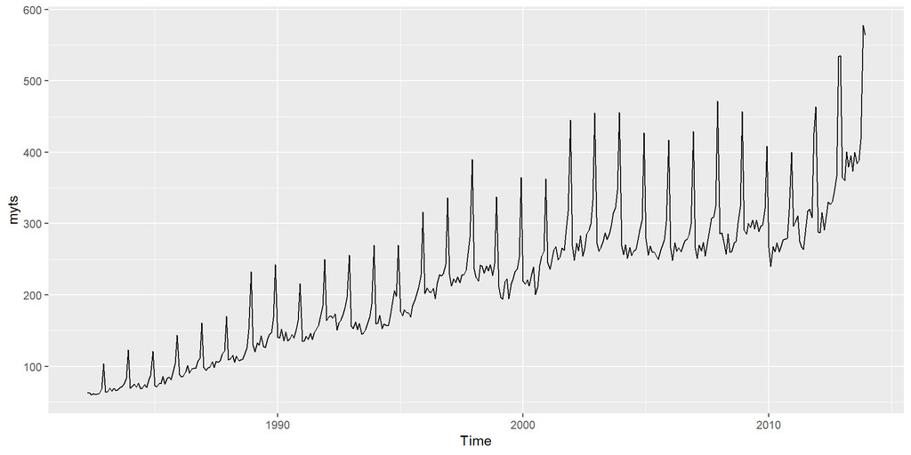

```r
autoplot(myts)
```

The seasonality appears to be quite similar across all years, with the seasonality being flat for most months except the beginning and the end of each year. For all the years in the data shown above, the sales spiked in December due to the shopping seasonality effect. Starting with year 1997, there appears to be a noticeable decline in sales in February of each year, which as noted above could be due to the spikes in sales during the holiday season comprised of the months of December and January. The data set appears to have started in April of 1982.

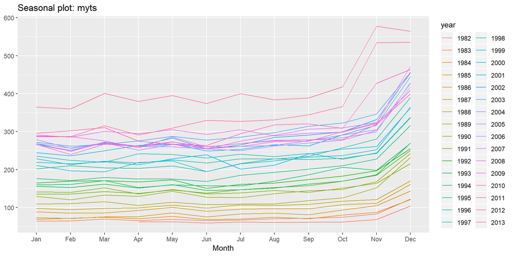

```r
ggseasonplot(myts)
```

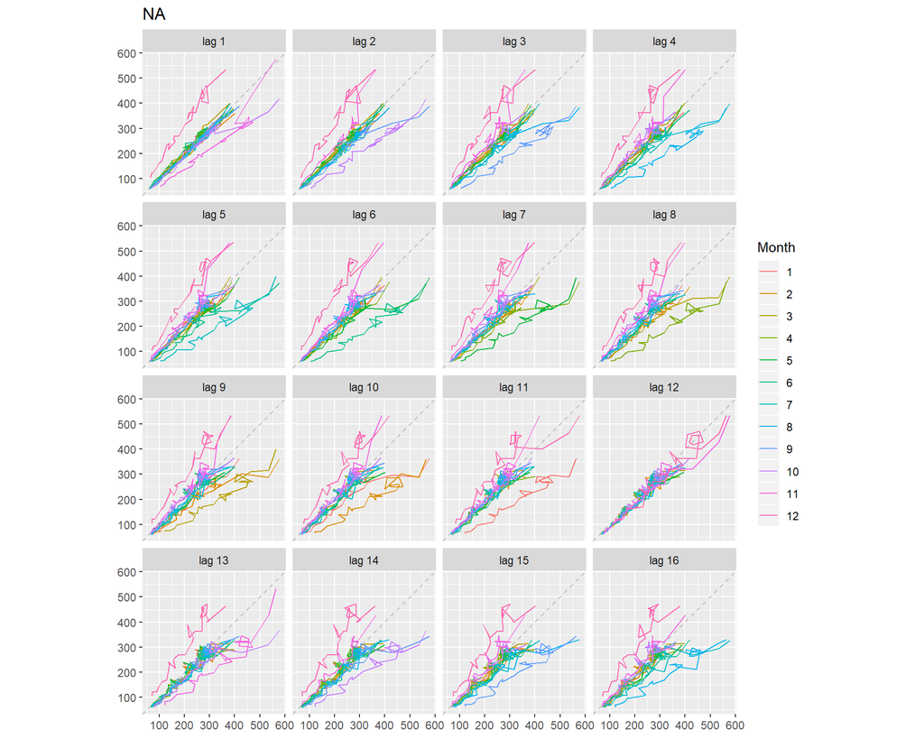

```r
gglagplot(myts)
```

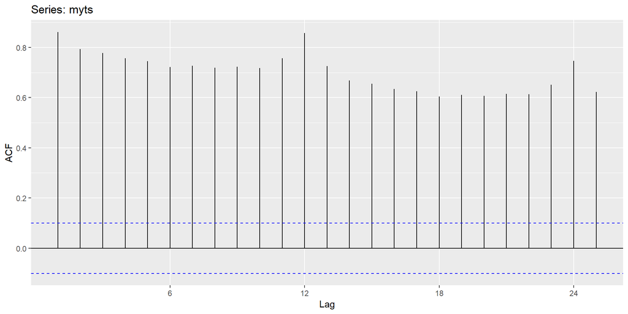

```r
ggAcf(myts)
```

## Question 2.7

**Similar to the previous question, we are asked to evaluate data with a variety of plots; however, this question is asking us to compare groups to each other, which may require some additional formatting.**

The arrivals data set comprises quarterly international arrivals (in thousands) to Australia from Japan, New Zealand, UK and the US.

```r
data(arrivals)
```

Use `autoplot()`, `ggseasonplot()` and `ggsubseriesplot()` to compare the differences between the arrivals from these four countries.

**Fortunately, all countries can be displayed in one autoplot**

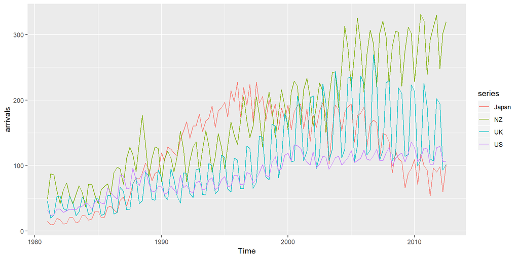

```r
autoplot(arrivals)
```

**However, the remaining plots will have to be organized into grids**

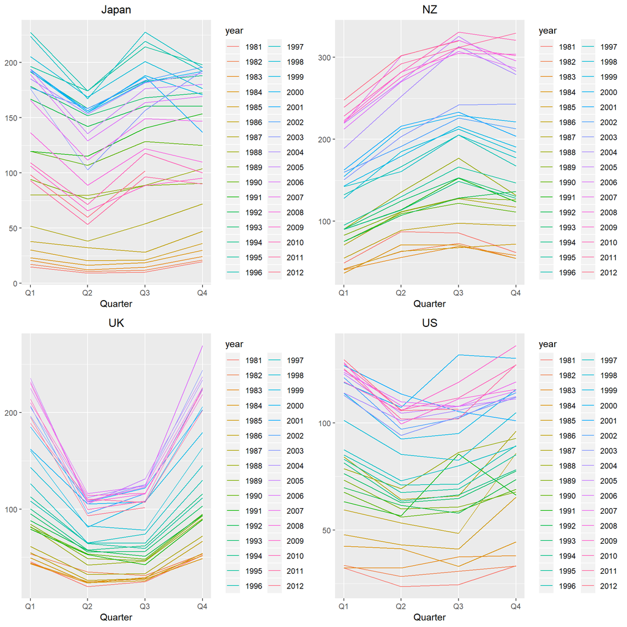

```r
p1 <- ggseasonplot(arrivals[, c("Japan")]) + theme(plot.title = element_text(hjust = 0.5)) + ggtitle("Japan")
p2 <- ggseasonplot(arrivals[, c("NZ")]) + theme(plot.title = element_text(hjust = 0.5)) + ggtitle("NZ")
p3 <- ggseasonplot(arrivals[, c("UK")]) + theme(plot.title = element_text(hjust = 0.5)) + ggtitle("UK")
p4 <- ggseasonplot(arrivals[, c("US")]) + theme(plot.title = element_text(hjust = 0.5)) + ggtitle("US")
grid.arrange(p1, p2, p3, p4, ncol = 2)
```

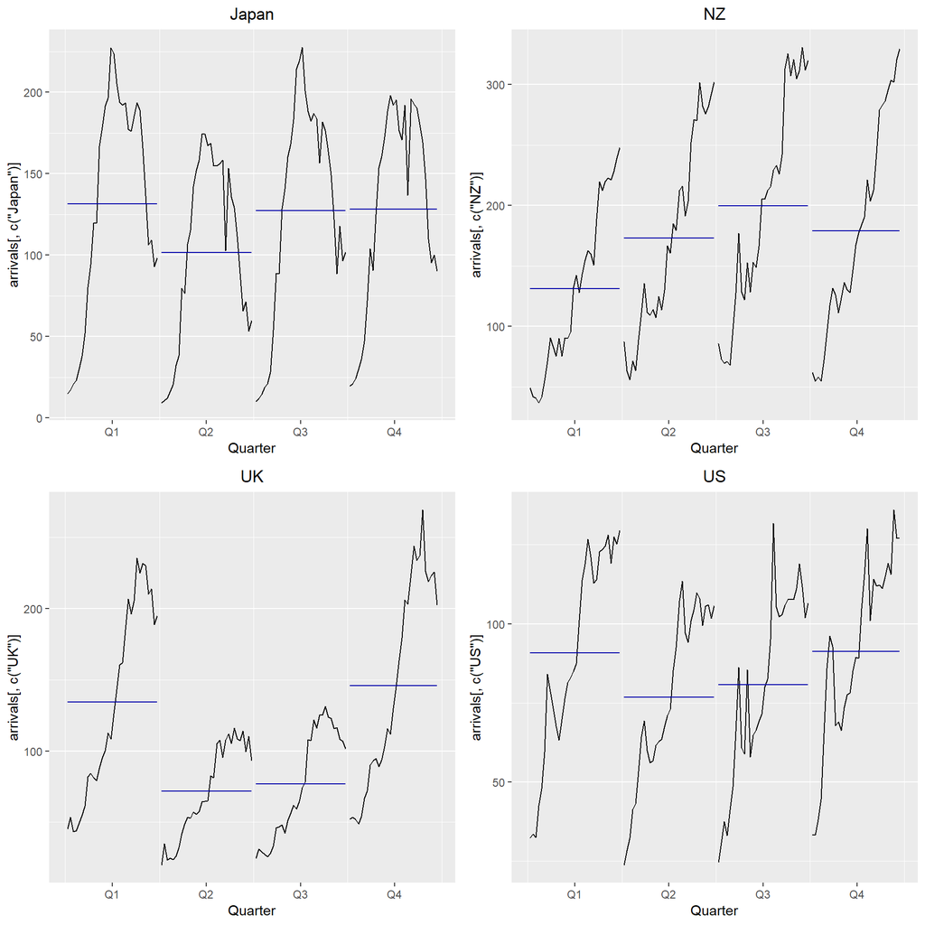

```r
p1 <- ggsubseriesplot(arrivals[, c("Japan")]) + theme(plot.title = element_text(hjust = 0.5)) + ggtitle("Japan")
p2 <- ggsubseriesplot(arrivals[, c("NZ")]) + theme(plot.title = element_text(hjust = 0.5)) + ggtitle("NZ")
p3 <- ggsubseriesplot(arrivals[, c("UK")]) + theme(plot.title = element_text(hjust = 0.5)) + ggtitle("UK")
p4 <- ggsubseriesplot(arrivals[, c("US")]) + theme(plot.title = element_text(hjust = 0.5)) + ggtitle("US")
grid.arrange(p1, p2, p3, p4, ncol = 2)
```

Can you identify any unusual observations?

**First, it appears that NZ has a disctinctly positive trend while most of the other countries do not; the US is close but it looks much less prominent. Second, Japan appears to be either have a cyclical nature, or be trending downward; it is hard to tell without more data. Third, the UK appears to experience a very large seasonality that scales with the number of arrivals. Note, all countries appear to have seasonality scale somewhat with the number of arrivals, but the UK’s variation is prominent. Fourth, the UK and US have Q2 and Q3 as their quarters with lower number of arrivals while Japan’s is Q2 and NZ’s is Q1, which indicates these time series are not in sync with their seasonality cycles.**

## Question 2.10

**This question asks us to plot a diff chart for time series data. The `diff()` function takes the difference between consecutive measurements, known as differencing. Differencing can help stabilize the mean by removing or reducing trend and seasonality, which could leave only white noise so that a variety of models can be applied to the data.**

`dj` contains 292 consecutive trading days of the Dow Jones Index. Use `ddj <- diff(dj)` to compute the daily changes in the index. Plot ddj and its ACF. Do the changes in the Dow Jones Index look like white noise?

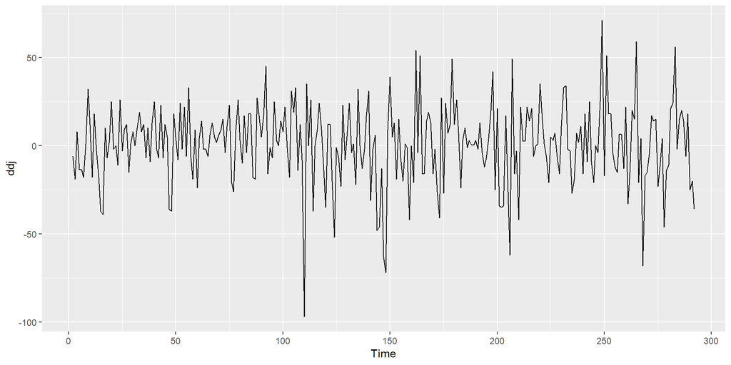

```r
ddj <- diff(dj)
autoplot(ddj)
```

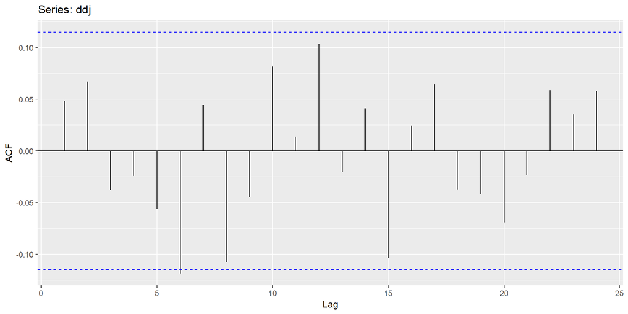

```r
ggAcf(ddj)
```

**On initial inspection of the ACF plot, we see that that results contain multiple lags being near the rule of thumb limit $\pm2/\sqrt{T}$, but ultimately that they are within the boundaries; therefore, using the `diff()` function results in data being ‘stabalized’, or containing only white noise. As noted in the book, at a p-value of 0.05 one spike in 20 is not unexpected given the alpha value, which we can see here.**

# Chapter 3: The Forecaster’s Toolbox

## Question 3.1

**In this problem, we will be looking at stabilizing variance for various data sets using box-cox transformations. The reason for doing this is that variance can scale with the predicted value, which makes it difficult to implement a model. By applying a box-cox transformation, we are able to stabilize this variance, which basically means trying to keep it constant so that we can apply an appropriate model afterwards. Fortunately, there is a function that chooses the appropriate *lambda* ($\lambda$) value (`BoxCox.lambda()`).**

For the following series, find an appropriate Box-Cox transformation in order to stabilise the variance.

**Here we will use the `BoxCox.lambda()` function to find an optimal value, plot it, and compare it to the orginal time series.**

- `usnetelec`

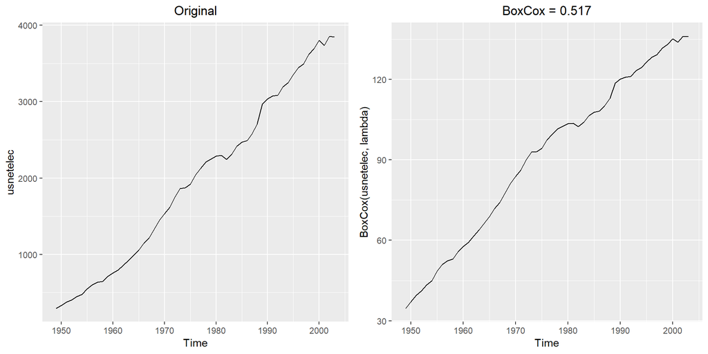

```r
lambda <- BoxCox.lambda(usnetelec)
p1 <- autoplot(usnetelec) + theme(plot.title = element_text(hjust = 0.5)) + ggtitle("Original")
p2 <- autoplot(BoxCox(usnetelec, lambda)) + theme(plot.title = element_text(hjust = 0.5)) + ggtitle(paste("BoxCox =", round(lambda,3), sep = " "))
grid.arrange(p1, p2, ncol = 2)
```

- `usgdp`

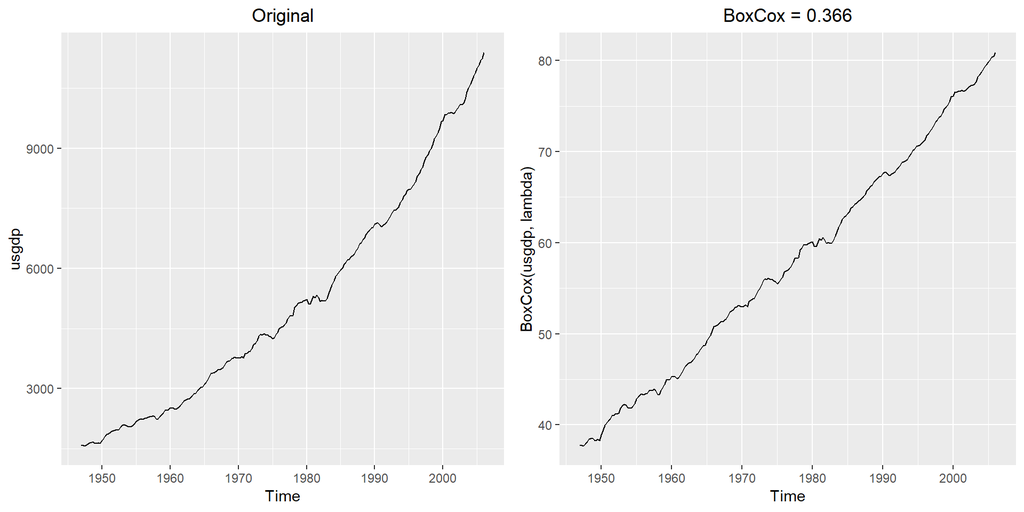

```r
lambda <- BoxCox.lambda(usgdp)
p1 <- autoplot(usgdp) + theme(plot.title = element_text(hjust = 0.5)) + ggtitle("Original")
p2 <- autoplot(BoxCox(usgdp, lambda)) + theme(plot.title = element_text(hjust = 0.5)) + ggtitle(paste("BoxCox =", round(lambda,3), sep = " "))
grid.arrange(p1, p2, ncol = 2)
```

- `mcopper`

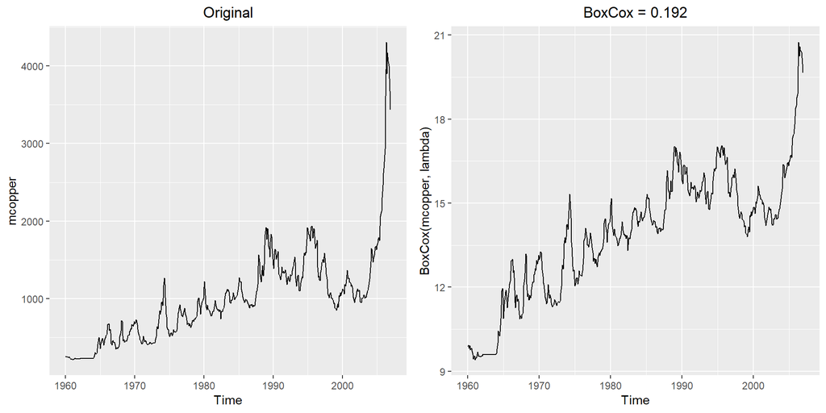

```r
lambda <- BoxCox.lambda(mcopper)
p1 <- autoplot(mcopper) + theme(plot.title = element_text(hjust = 0.5)) + ggtitle("Original")
p2 <- autoplot(BoxCox(mcopper, lambda)) + theme(plot.title = element_text(hjust = 0.5)) + ggtitle(paste("BoxCox =", round(lambda,3), sep = " "))
grid.arrange(p1, p2, ncol = 2)
```

- `enplanements`

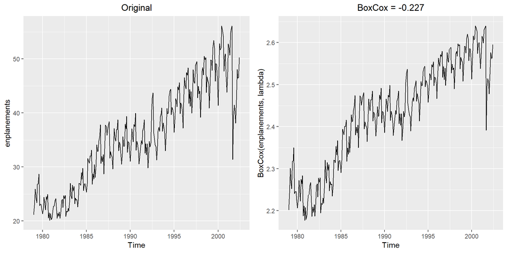

```r
lambda <- BoxCox.lambda(enplanements)
p1 <- autoplot(enplanements) + theme(plot.title = element_text(hjust = 0.5)) + ggtitle("Original")
p2 <- autoplot(BoxCox(enplanements, lambda)) + theme(plot.title = element_text(hjust = 0.5)) + ggtitle(paste("BoxCox =", round(lambda,3), sep = " "))
grid.arrange(p1, p2, ncol = 2)
```

**From this analysis, we can see that one property of Box Cox transformations is tha they try to find the best lambda value that linearizes the data. The best examples of this are in the `usnetelec` and `usgdp` data sets. Good examples of variance getting stablized in the seasonal patterns are in the `mcopper` and `enplanements` graphs.**

## Question 3.8

**In this excersise we will be evaluating the prediction accuracy from a previous exercise. We will be using the `accuracy` function which returns an array of error measurements of training and test data. Additional findings are written below.**

For your retail time series (from Exercise 3 in Section 2.10):

1. Split the data into two parts using

```r
myts.train <- window(myts, end=c(2010,12))
myts.test <- window(myts, start=2011)
```

2. Check that your data have been split appropriately by producing the following plot.

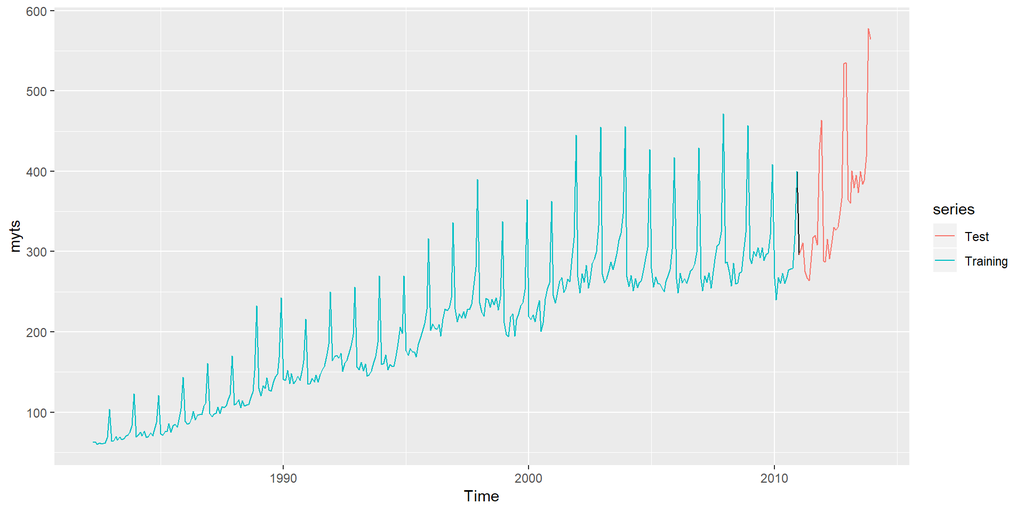

```r
autoplot(myts) +
  autolayer(myts.train, series="Training") +
  autolayer(myts.test, series="Test")
```

3. Calculate forecasts using snaive applied to myts.train.

```r
fc <- snaive(myts.train)
```

4. Compare the accuracy of your forecasts against the actual values stored in myts.test.

```r
accuracy(fc,myts.test)
```

```
##                     ME     RMSE      MAE       MPE      MAPE     MASE
## Training set  7.772973 20.24576 15.95676  4.702754  8.109777 1.000000
## Test set     55.300000 71.44309 55.78333 14.900996 15.082019 3.495907
##                   ACF1 Theil's U
## Training set 0.7385090        NA
## Test set     0.5315239  1.297866
```

5. Check the residuals.

   Do the residuals appear to be uncorrelated and normally distributed?

   **No, they do not. The ACF plot indicates many lags fall outside of the limit. Also, there is a noticeable trend in the lags; they are decreasing and appear to have a sinusoidal pattern, indicating there is an uncaptured trend and sesonality/cyclicity pattern. Additionally, the Ljung box test returns a p-value below the critical level (0.05) which indicates there are still autocorrelations within the residuals. As for normality, the requirements do not appear to be met either as the distribution does not appear to be centered around zero and looks like it is skewed left but also with a large positive outlier.**

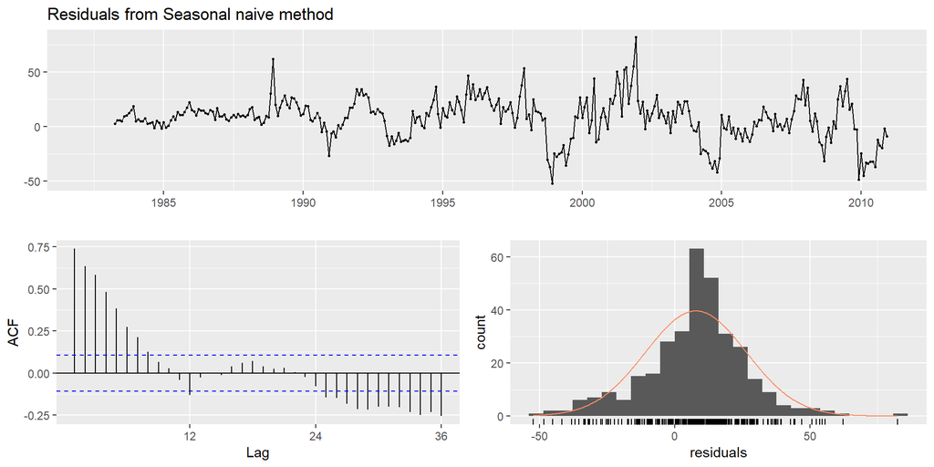

```
##
##  Ljung-Box test
##
## data:  Residuals from Seasonal naive method
## Q* = 624.45, df = 24, p-value < 2.2e-16
##
## Model df: 0.   Total lags used: 24
```

```r
checkresiduals(fc)
```

6. How sensitive are the accuracy measures to the training/test split?

   **One way of testing this question is to try sets of different training/test splits**

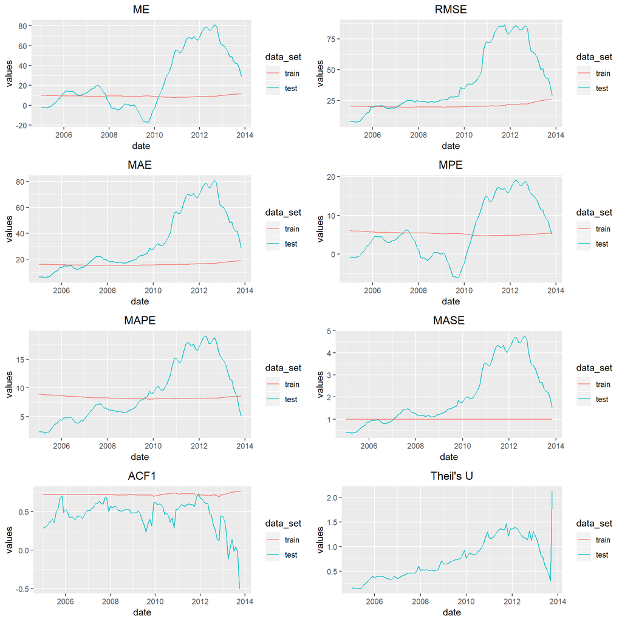

```r
l_t <- list()
ind_t <- 1
for(i in 2005:2013) {
  for(j in 1:12) {
    l_t[[ind_t]] = c(i, j)
    ind_t <- ind_t + 1
  }
}

df <- data.frame()
for(i in 1:(length(l_t)-1)) {
    myts.train <- window(myts, end=c(l_t[[i]][1],l_t[[i]][2]))
    myts.test <- window(myts, start=c(l_t[[i + 1]][1], l_t[[i + 1]][2]))
    fc <- snaive(myts.train)
    df <- rbind(df, cbind(stack(accuracy(fc,myts.test)[1,]), year = l_t[[i]][1], month=l_t[[i]][2], index=i, data_set = 'train'))
    df <- rbind(df, cbind(stack(accuracy(fc,myts.test)[2,]), year = l_t[[i]][1], month=l_t[[i]][2], index=i, data_set = 'test'))
}

df$date <- base::as.Date(paste0(df$year,"-",str_pad(df$month, 2, pad="0"),"-",'01'))

p1 <- ggplot(df[df$ind=='ME',], aes(x=date, y=values, color=data_set)) + geom_line() + theme(plot.title = element_text(hjust = 0.5)) + ggtitle("ME") + scale_x_date(date_breaks = '2 year', labels = date_format('%Y'))
p2 <- ggplot(df[df$ind=='RMSE',], aes(x=date, y=values, color=data_set)) + geom_line() + theme(plot.title = element_text(hjust = 0.5)) + ggtitle("RMSE") + scale_x_date(date_breaks = '2 year', labels = date_format('%Y'))
p3 <- ggplot(df[df$ind=='MAE',], aes(x=date, y=values, color=data_set)) + geom_line() + theme(plot.title = element_text(hjust = 0.5)) + ggtitle("MAE") + scale_x_date(date_breaks = '2 year', labels = date_format('%Y'))
p4 <- ggplot(df[df$ind=='MPE',], aes(x=date, y=values, color=data_set)) + geom_line() + theme(plot.title = element_text(hjust = 0.5)) + ggtitle("MPE") + scale_x_date(date_breaks = '2 year', labels = date_format('%Y'))
p5 <- ggplot(df[df$ind=='MAPE',], aes(x=date, y=values, color=data_set)) + geom_line() + theme(plot.title = element_text(hjust = 0.5)) + ggtitle("MAPE") + scale_x_date(date_breaks = '2 year', labels = date_format('%Y'))
p6 <- ggplot(df[df$ind=='MASE',], aes(x=date, y=values, color=data_set)) + geom_line() + theme(plot.title = element_text(hjust = 0.5)) + ggtitle("MASE") + scale_x_date(date_breaks = '2 year', labels = date_format('%Y'))
p7 <- ggplot(df[df$ind=='ACF1',], aes(x=date, y=values, color=data_set)) + geom_line() + theme(plot.title = element_text(hjust = 0.5)) + ggtitle("ACF1") + scale_x_date(date_breaks = '2 year', labels = date_format('%Y'))
p8 <- ggplot(df[df$ind=="Theil's U",], aes(x=date, y=values, color=data_set)) + geom_line() + theme(plot.title = element_text(hjust = 0.5)) + ggtitle("Theil's U") + scale_x_date(date_breaks = '2 year', labels = date_format('%Y'))
grid.arrange(p1, p2, p3, p4, p5, p6, p7, p8, ncol=2)
```

**For a simple thought exercise, here we ran an array of training/test splits to see how the various error rates changed due to the selected groupings. In this example, we have set the total data to be the same lenght in all trials but only varied the boundary date for the training/test sets. The first thing we notice is that the error is very sensitive when we pick a boundary date between 2011 and 2012. It appears this may be due an apparent shifting trend that happens around that time. Also, the further back in the training set we pick, the more ‘averaged’ the errors become, which means we may have overall better performance, but not better performance for the most recent predictions. As discussed in the reading, the further out a prediction is from the trained model, the greater the uncertainty that surrounds it.**

# Chapter 6: Time Series Decomposition

## Question 6.2

**This example will cover methods to do multiplicative decomposition as well as evaluation of trend, season, and cyclical patterns. Additionally, we will investigate the influence that a single outlier has on the data.**

The `plastics` data set consists of the monthly sales (in thousands) of product A for a plastics manufacturer for five years.

1. Plot the time series of sales of product A. Can you identify seasonal fluctuations and/or a trend-cycle?  
   **There definitely appears to be seasonal fluctuations in the data which appear to have relatively constant variance over the visible time period. There also does appear to be a positive trend; however, due to the large relative variance in the seasonlity, the actual significance of the trend may not be as large as indicated.**

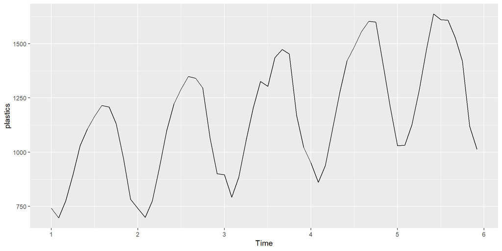

```r
autoplot(plastics)
```

2. Use a classical multiplicative decomposition to calculate the trend-cycle and seasonal indices.

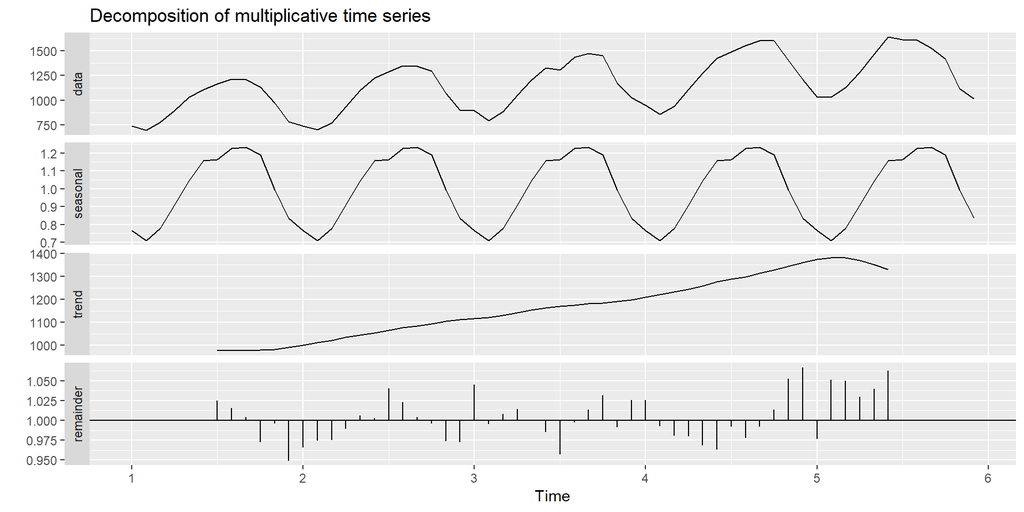

```r
plastics %>%
  decompose(type='multiplicative') -> plastics_decomp
autoplot(plastics_decomp)
```

3. Do the results support the graphical interpretation from part a?  
   **The results do appear to aggree with our interpretation. The trend does appear to be significant enough to be captured by this method, and the variance of the seasonality was definitely captured. However, it appears there is some sinusoidal pattern that is still present in the remainder, so this might not be the best type of fit. From the intial inspection, it appeared the variance was fairly constant, in which case, an additive model should be used. From the output below, we see that an additive model does a similar, and possibly better, job which is consistent with the initial graphical interpretation.**

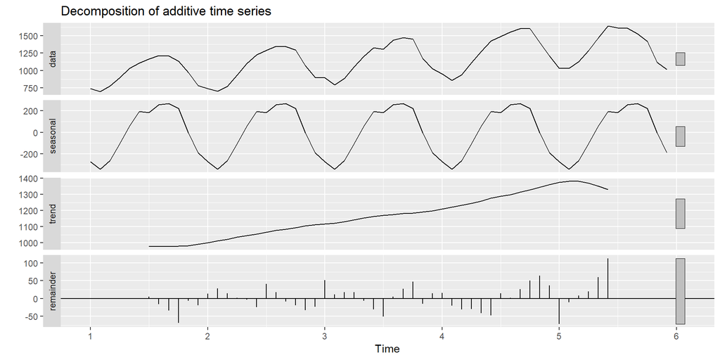

```r
plastics %>%
  decompose(type='additive') -> plastics_decomp_2
autoplot(plastics_decomp_2)
```

4. Compute and plot the seasonally adjusted data.

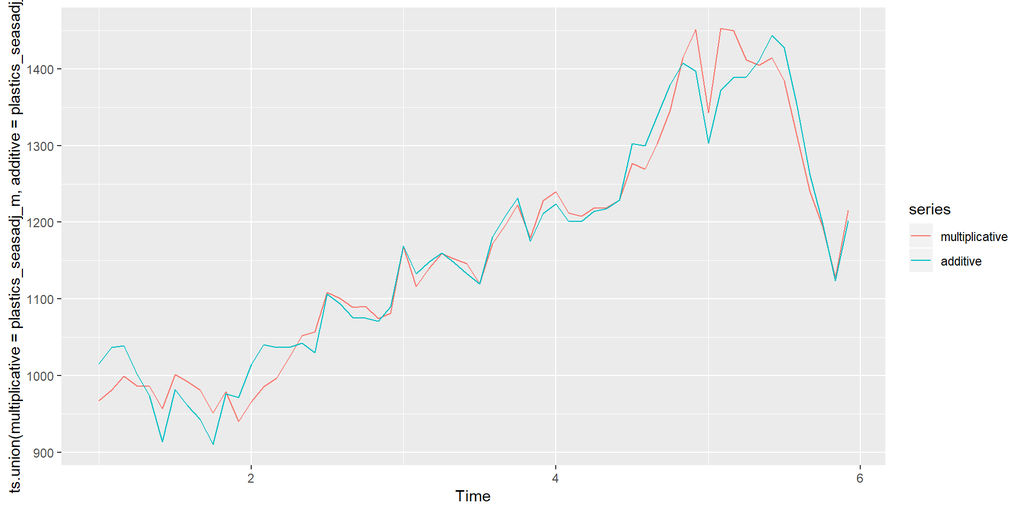

```r
plastics_seasadj_m <- plastics_decomp %>% seasadj()
plastics_seasadj_a <- plastics_decomp_2 %>% seasadj()

autoplot(ts.union('multiplicative' = plastics_seasadj_m, 'additive' = plastics_seasadj_a))
```

5. Change one observation to be an outlier (e.g., add 500 to one observation), and recompute the seasonally adjusted data. What is the effect of the outlier?  
   **In the below chart, we can generate mutliple samples of outlier locations. Here we can see that the seasonally adjusted data appears to have transferred much of the additional value to the seasonally adjusted data, and was not accidentally captured as a pattern.**

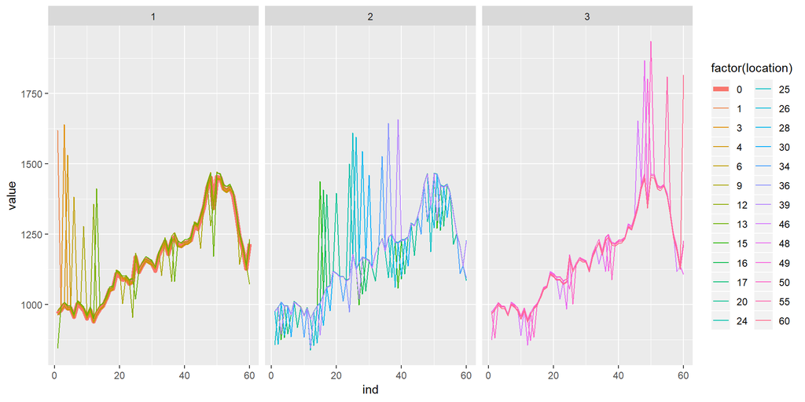

```r
set.seed(2345245)
n_samples <- 25
plastics_l_loc <- list()
plastics_l_data <- list()
ind_t <- 1

random_locations <- sample(seq(1, length(plastics), 1), n_samples, replace = FALSE)

for(j in random_locations){
  plastics_t <- plastics
  plastics_t[j] =  plastics_t[j] + 500
  plastics_decomp_m_t <- plastics_t %>% decompose(type='multiplicative')
  plastics_seasadj_m_t <- plastics_decomp_m_t %>% seasadj()
  plastics_l_loc[[ind_t]] <- j
  plastics_l_data[[ind_t]] <- plastics_seasadj_m_t
  ind_t <- ind_t + 1
}

df <- data.frame()
for(i in 1:length(plastics_l_loc)) {
  df_t <- data.frame()
  df_t <- cbind('order' = i, 'location' = plastics_l_loc[[i]], 'ind' =  seq(1, 60, 1), 'value' = data.frame('value' = c(as.matrix(plastics_l_data[[i]]))))
  df <- rbind(df, df_t)
}

df <- rbind(df, data.frame('order' = 0, 'location' = 0, 'ind' =  seq(1, 60, 1), 'value' = data.frame('value' = c(as.matrix(plastics_seasadj_m)))))

ggplot(df[(df$location>0 & df$location<65)|df$location==0,],
       aes(x=ind, y=value, color=factor(location))) +
  geom_line(aes(size=factor(location))) +
  scale_size_manual(values = c(2, rep(0.5,59))) +
  facet_grid(~factor(ifelse(location<15,1,ifelse(location<45,2,3))))
```

6. Does it make any difference if the outlier is near the end rather than in the middle of the time series?  
   **It seems like the seasonally adjusted data is more influenced by outliers in the middle, since the whole time series appears to be affected whereas outliers at the end of time series do not appear to have as siginficant of an affect on the earlier points.**

## Question 6.6

**In this problem, we will walk through an STL decomposition, experiment with various parameters, and compare naive vs robust models.**

We will use the `bricksq` data (Australian quarterly clay brick production. 1956â“1994) for this exercise.

1. Use an STL decomposition to calculate the trend-cycle and seasonal indices. (Experiment with having fixed or changing seasonality.) Note, the `t.window` and `s.window` parameters must be odd

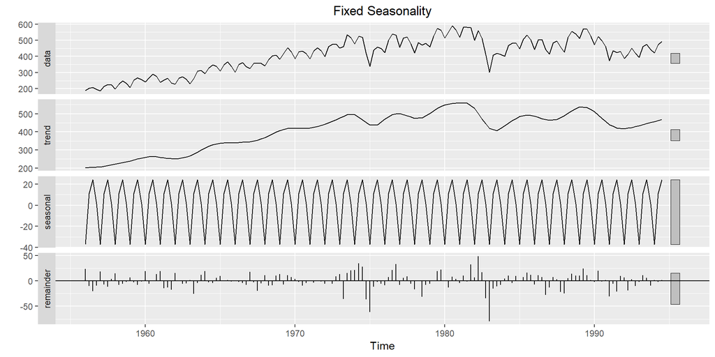

```r
fixed_t_window=11
changing_t_window=11
changing_s_window=7
bricksq %>%
  stl(t.window=fixed_t_window, s.window = 'periodic') -> bricksq_stl_fixed

bricksq_stl_fixed %>% autoplot() + theme(plot.title = element_text(hjust = 0.5)) + ggtitle("Fixed Seasonality")
```

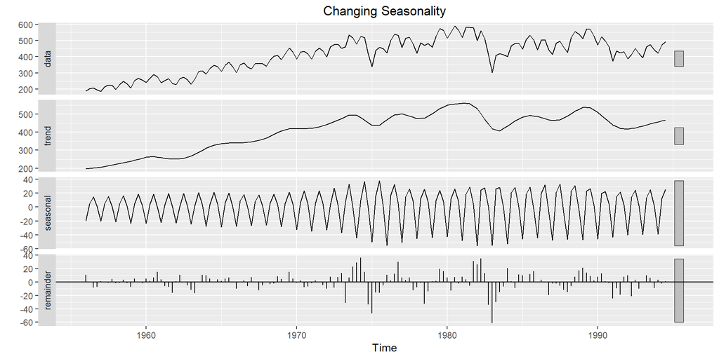

```r
bricksq %>%
  stl(t.window=changing_t_window, s.window = changing_s_window) -> bricksq_stl_changing

bricksq_stl_changing %>% autoplot() + theme(plot.title = element_text(hjust = 0.5)) + ggtitle("Changing Seasonality")
```

2. Compute and plot the seasonally adjusted data.

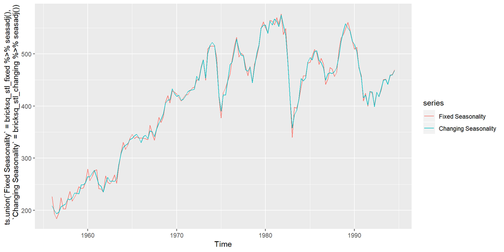

```r
autoplot(
  ts.union(
    'Fixed Seasonality' = bricksq_stl_fixed %>% seasadj(),
    'Changing Seasonality' = bricksq_stl_changing %>% seasadj()
  )
)
```

3. Use a naÃ¯ve method to produce forecasts of the seasonally adjusted data.

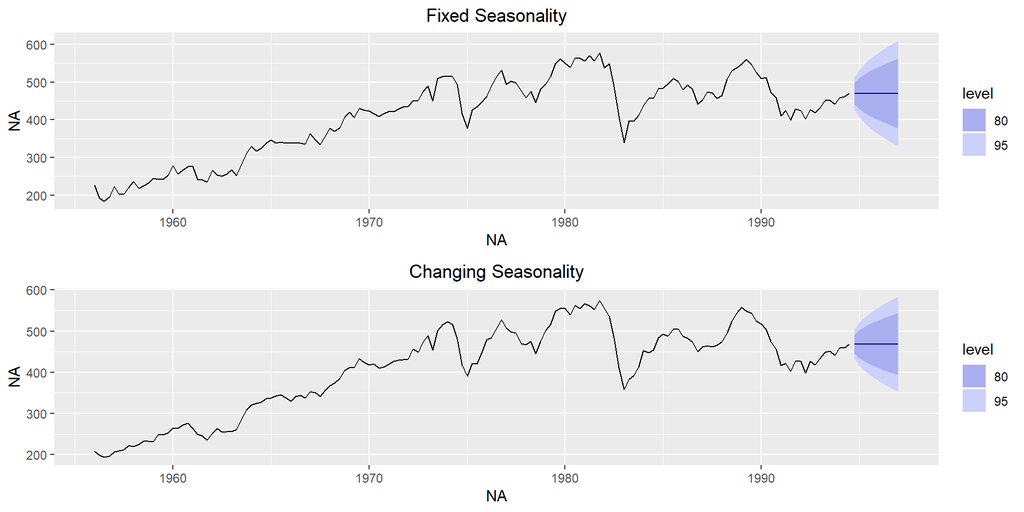

```r
bricksq_stl_fixed %>%
  seasadj() %>%
  naive() -> bricksq_stl_fixed_naive

bricksq_stl_changing %>%
  seasadj() %>%
  naive() -> bricksq_stl_changing_naive

p1 <- bricksq_stl_fixed_naive %>% autoplot() + theme(plot.title = element_text(hjust = 0.5)) + ggtitle("Fixed Seasonality")
p2 <- bricksq_stl_changing_naive %>% autoplot() + theme(plot.title = element_text(hjust = 0.5)) + ggtitle("Changing Seasonality")
grid.arrange(p1, p2, ncol=1)
```

4. Use `stlf()` to reseasonalise the results, giving forecasts for the original data.

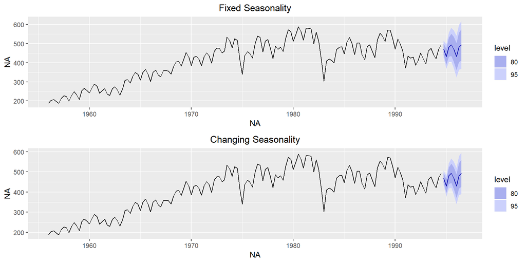

```r
bricksq_stlf_fixed_naive <- stlf(bricksq, method='naive', t.window=fixed_t_window, s.window='periodic')
bricksq_stlf_changing_naive <- stlf(bricksq, method='naive', t.window=changing_t_window, s.window=changing_s_window)

p1 <- bricksq_stlf_fixed_naive %>% autoplot() + theme(plot.title = element_text(hjust = 0.5)) + ggtitle("Fixed Seasonality")
p2 <- bricksq_stlf_changing_naive %>% autoplot() + theme(plot.title = element_text(hjust = 0.5)) + ggtitle("Changing Seasonality")
grid.arrange(p1, p2, ncol=1)
```

5. Do the residuals look uncorrelated?

**Plot Fixed Seasonality Residuals**

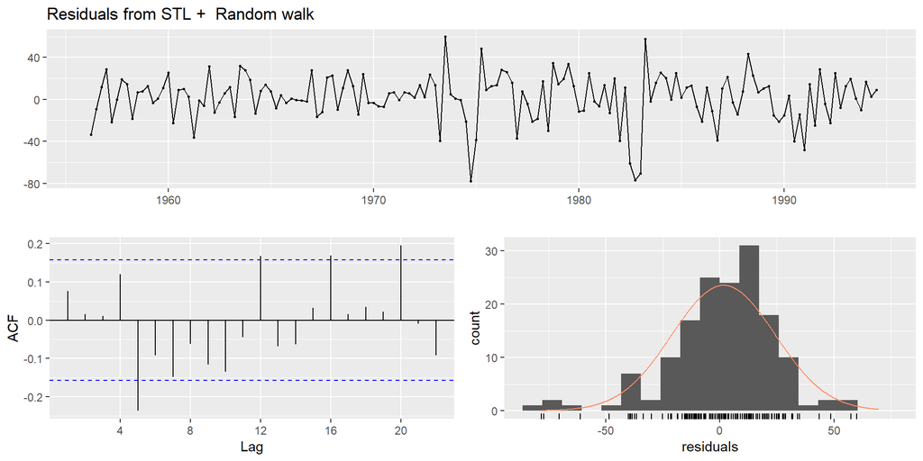

```
##
##  Ljung-Box test
##
## data:  Residuals from STL +  Random walk
## Q* = 17.925, df = 8, p-value = 0.02179
##
## Model df: 0.   Total lags used: 8
```

```r
checkresiduals(bricksq_stlf_fixed_naive)
```

**Plot Changing Seasonality Residuals**

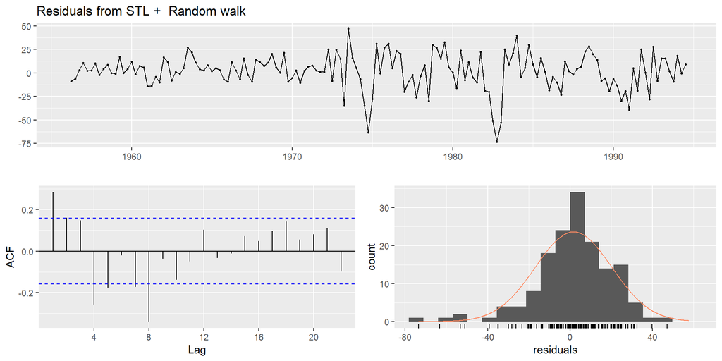

```
##
##  Ljung-Box test
##
## data:  Residuals from STL +  Random walk
## Q* = 59.795, df = 8, p-value = 5.113e-10
##
## Model df: 0.   Total lags used: 8
```

```r
checkresiduals(bricksq_stlf_changing_naive)
```

**No, the results do not look uncorrelated. Both methods show that there are outliers in the ACF plots and the residusal distributions appear to have a left skew. Additionally, neither test passes a Box-Ljung test using a significance level of p = 0.05**

6. Repeat with a robust STL decomposition. Does it make much difference?

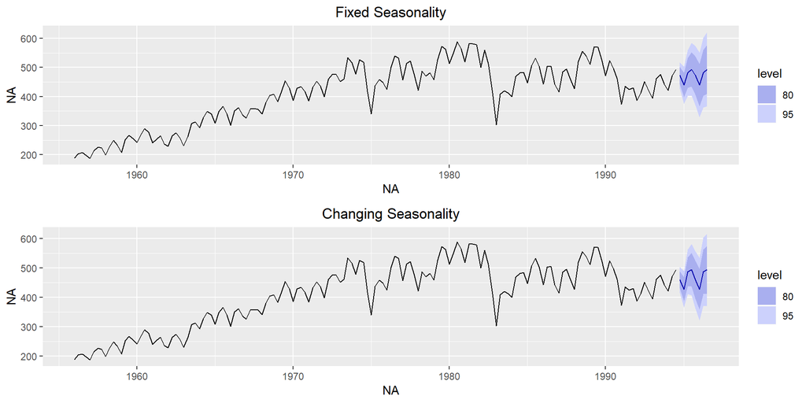

```r
bricksq_stlf_fixed_naive_robust <- stlf(bricksq, method='naive', t.window=fixed_t_window, s.window='periodic', robust = TRUE)
bricksq_stlf_changing_naive_robust <- stlf(bricksq, method='naive', t.window=changing_t_window, s.window=changing_s_window, robust = TRUE)

p1 <- bricksq_stlf_fixed_naive_robust %>% autoplot() + theme(plot.title = element_text(hjust = 0.5)) + ggtitle("Fixed Seasonality")
p2 <- bricksq_stlf_changing_naive_robust %>% autoplot() + theme(plot.title = element_text(hjust = 0.5)) + ggtitle("Changing Seasonality")
grid.arrange(p1, p2, ncol=1)
```

**Plot Fixed Seasonality Residuals**

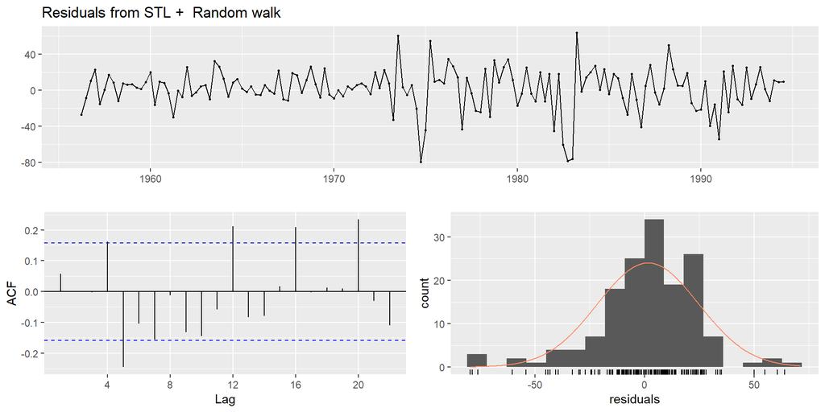

```
##
##  Ljung-Box test
##
## data:  Residuals from STL +  Random walk
## Q* = 19.978, df = 8, p-value = 0.01042
##
## Model df: 0.   Total lags used: 8
```

```r
checkresiduals(bricksq_stlf_fixed_naive_robust)
```

**Plot Changing Seasonality Residuals**

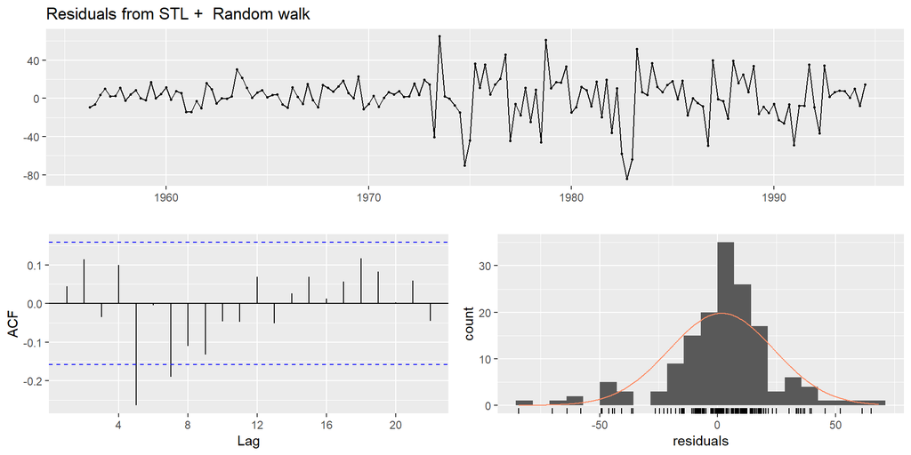

```
##
##  Ljung-Box test
##
## data:  Residuals from STL +  Random walk
## Q* = 23.24, df = 8, p-value = 0.00307
##
## Model df: 0.   Total lags used: 8
```

```r
checkresiduals(bricksq_stlf_changing_naive_robust)
```